# DNA Methylation and Expression Network Analysis with SMITE

##### Author: Samantha Schaffner

##### Date: Sept 16, 2021

## Overview of SMITE

The Significance-based Modules Integrating the Transcriptome and Epigenome (SMITE) package ( [Wijetunga et al. 2017](https://bmcbioinformatics.biomedcentral.com/articles/10.1186/s12859-017-1477-3) ) can be used to integrate multiple types of 'omics data (primarily focused on DNA methylation and expression) with gene scoring and network analysis. The objectives of SMITE are to determine which genes have changes to DNA methylation and/or expression between experimental groups, and then examine with network analysis how the encoded proteins interact with one another. The full SMITE workflow will return protein-protein interaction "modules" containing genes which have altered DNA methylation and/or expression, i.e. genes that are hypothesized to be co-regulated by multiple 'omics.

SMITE builds upon a previous method called Functional Epigenetic Modules (FEM; [Jiao et al. 2014](https://academic.oup.com/bioinformatics/article/30/16/2360/2748243) ) by introducing a much wider array of customization in terms of which gene features you are interested in, how important each feature is, and whether or not you want to specify a directional relationship between DNA methylation and expression.

## Main steps in workflow

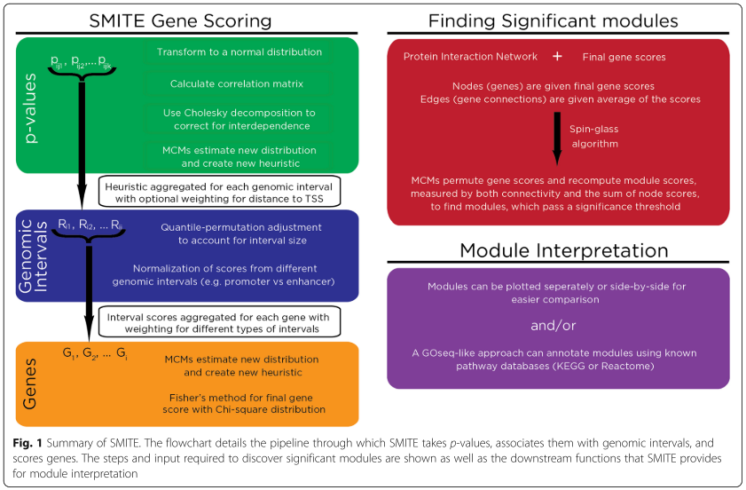

Summary of steps in SMITE (Fig. 1, Wijetunga et al. 2017)

**1. Gather DNA methylation and expression information**

The first step is to create a "PvalueAnnotation" object which can store the p-values from different 'omics analyses and genome annotation information.

**2. Combine site-specific DNA methylation p-values to obtain gene-level p-values**

The second step performs data reduction on the CpG-level DNA methylation data, with the goal of obtaining a unit that is meaningful to combine with expression. SMITE will combine DNA methylation p-values across gene features (default promoter and gene body).

**3. Score genes**

At this stage, DNA methylation and expression p-values are combined to create a single gene-level score for each gene. The DNA methylation data can be weighted by gene feature, and the directional relationship between DNA methylation at each feature and expression can be optionally specificied.

**4. Find regulatory modules**

The next stage annotates gene scores onto pre-existing protein-protein interaction networks, which can be retrived from a database like REACTOME or STRING. Each gene represents a node in the network, and connections between genes are edges. A spin-glass algorithm is applied to find sub-networks of highly scoring genes.

**5. Module interpretation**

Modules can be plotted, and optionally you can perform pathway enrichment on the modules.

## Data for tutorial

We will be using DNA methylation and gene expression data from Lund human mesencephalic (LUHMES) cells, a fetal midbrain cell line that is commonly differentiated to dopaminergic neurons to model Parkinson's disease in vitro. We'll be looking at the effect of overexpressing alpha-synuclein, a gene implicated in Parkinson's disease. DNA methylation data was generated with the Illumina EPIC BeadChip microarray (Kobor lab), and gene expression data was generated with RNA-seq (Dr. Tiago Outeiro, University of Goettingen). For more information, see [Paiva et al., 2017](https://academic.oup.com/hmg/article/26/12/2231/3084502) and [Schaffner et al., 2021](https://www.biorxiv.org/content/10.1101/2021.06.12.448150v1) (preprint).

Although additional 'omics (DNA hydroxymethylation and ChIP-seq) exist for these cells, we'll focus on two for the sake of the tutorial. See the [code for Schaffner et al., 2021](https://github.com/samschaf/LUHMES) for a more detailed example of integrating several 'omics with SMITE.

## Libraries and functions

```r
setwd("~/")

options(stringsAsFactors = FALSE)
library(SMITE)
library(dplyr)
library(reshape2)
library(ggplot2)

source("~/KoborLab/kobor_space/shared_coding_resource/SMITE/plotModule2.R")
#I altered the plotModule function included in the SMITE package ("plotModule2.R") after I noticed the original function was a bit misleading. It was set to plot any DNAm value of 1 as "high", anything significant other than 1 as "low", and anything non-significant as "medium." So I tweaked some parameters to plot any delta beta < 0 as "Hypo" for hypomethylated, and any delta beta > 0 as "Hyper" for hypermethylated. I also renamed the "medium" to "NS" for non-significant in both the DNAm and expression categories.
source("~/KoborLab/kobor_space/shared_coding_resource/SMITE/annotateModification2.R") #This fixes a bracket typo in a conditional loop (line 106) where if there is only one CpG sites per methylation feature, the effect for that feature should be returned (instead of attempting to weight the effect, which returns NA). Also added a condition where if all the p-values for a feature are 1, they will be replaced with 0.9999999999. Otherwise if all p-values are 1, all weights will be 0, resulting in NA for the weighted effect.
```

## Load and curate DNA methylation data

DNA methylation data should be formatted as a data frame with each row representing one CpG site, and columns containing chromosome, start, stop, effect size (delta beta), and adjusted p-value (FDR) in that order. Row names do not matter since SMITE will be using genome coordinates and not Illumina probe IDs for downstream analyses.

*For site-specific data, start/stop are the same (CpG position).

We'll be using a subsetted data frame containing 1000 CpG sites for the sake of the tutorial.

```r
#Load DNA methylation data - data frame containing chr, start, stop, effect size (delta beta), and adjusted p-value (FDR)
methylation <- read.csv("~/KoborLab/kobor_space/SWAG/Practicums/09_16_2021_SMITE_SS/LUHMES_DNAm.csv")
head(methylation)
```

```
##     chr     start      stop            DB   adj.P.Val
## 1  chr6   1614285   1614285  0.0014869801 0.741660014
## 2 chr10 121837310 121837310  0.0387675670 0.003606567
## 3  chr2 228191082 228191082  0.0046549671 0.683827976
## 4  chr6  36320401  36320401 -0.0395545209 0.019675426
## 5  chr6  26596151  26596151  0.0002808964 0.963108164
## 6  chr5  71710285  71710285  0.0278501452 0.046927705
```

```r
#checking for any p-values that are NA or zero
summary(methylation$adj.P.Val) #no NAs
```

```
##    Min. 1st Qu.  Median    Mean 3rd Qu.    Max.
##  0.0000  0.1188  0.4506  0.4597  0.7745  0.9994
```

```r
min(methylation$adj.P.Val) #smallest is non-zero
```

```
## [1] 8.783129e-09
```

## Load and curate RNA-seq data

Gene expression data should be formatted as a data frame with gene names as row names, effect size (log2FC) in the first column, and p-value in the second column.

Similar to above, we'll be using a subset of 1000 genes for the tutorial.

```r
expression <- read.csv("~/KoborLab/kobor_space/SWAG/Practicums/09_16_2021_SMITE_SS/LUHMES_expr.csv", row.names=1)
head(expression)
```

```
##              log2FoldChange padj
## NTPCR           -0.03958222 0.79
## AC007038.7       0.18343236 0.71
## TNFSF4           0.04544247 0.95
## CTC-366B18.4     0.53994065 0.16
## NRBF2P5          0.41817806 0.51
## CSPG4P5         -0.74051120 0.07
```

```r
#checking for any p-values that are NA or zero
summary(expression$padj) #no NAs
```

```
##    Min. 1st Qu.  Median    Mean 3rd Qu.    Max.
##  0.0000  0.2875  0.6000  0.5474  0.8200  1.0000
```

```r
min(expression$padj) #smallest is zero!
```

```
## [1] 0
```

```r
#replace zero p-values with minimum
expression$padj[expression$padj==0] <- min(expression$padj[expression$padj>0])
min(expression$padj) #0.01
```

```
## [1] 0.01
```

## Load bed file for genome annotation

SMITE requires a bed file that stores annotation information for genes according to their coordinates. This will be used to score the p-values according to their genes and features.

Since the RNA-seq is annotated with Ensembl, here I used Ensembl gene annotations from hg19. The BED file was exported from the UCSC genome table browser (http://genome.ucsc.edu/cgi-bin/hgTables) and saved previously.

```r
load("~/KoborLab/kobor_space/shared_coding_resource/SMITE/hg19_bed.RData")
head(hg19_bed)
```

```
##      V1        V2        V3      V4 V5 V6        V7        V8 V9 V10
## 1  chr7 127228398 127231759    ARF5  0  + 127228552 127231353  0   6
## 2 chr12   9092960   9102551    M6PR  0  -   9094413   9099000  0   7
## 3 chr11  64073049  64084210   ESRRA  0  +  64074651  64083438  0   7
## 4 chr12   2904118   2913124   FKBP4  0  +   2904305   2912424  0  10
## 5  chr2  72356366  72375167 CYP26B1  0  -  72359355  72374963  0   6
## 6  chr2  37458808  37476303 NDUFAF7  0  +  37458848  37475493  0  10
##                                      V11
## 1                 221,81,110,72,126,493,
## 2          1576,127,131,110,167,177,468,
## 3          159,337,117,129,171,270,1032,
## 4 292,145,143,121,157,91,84,186,240,808,
## 5              3382,285,156,276,225,408,
## 6 95,161,81,111,214,59,111,144,174,1026,
##                                                   V12
## 1                          0,738,1140,1721,2618,2868,
## 2                    0,2051,3040,3436,5053,5864,9123,
## 3                   0,1590,8373,8661,9163,9423,10129,
## 4     0,2185,2776,3753,4135,4897,5086,5439,6164,8198,
## 5                       0,3785,5523,5906,14751,18393,
## 6 0,440,4430,6091,9912,10969,12197,14386,15790,16469,
```

# Integrate data

## Making PvalueAnnotation object

To create the PvalueAnnotation, we will load in the bed file, DNA methylation, and expression data sequentially using separate functions in SMITE.

### Bed file (genome and gene features annotation)

When adding the bed file with makePvalueAnnotation(), we can specify the distance around the TSS which will be considered a "promoter." Here I am using +/-1kb.

```r
LUHMES_annotation <- makePvalueAnnotation(data = hg19_bed, gene_name_col = 4, promoter_upstream_distance = 1000, promoter_downstream_distance = 1000)
```

```
## Genes are duplicated.  Removing duplicates
```

### Adding expression data

Specify the columns in the expression data frame that contain p-value and effect sizes.

```r
LUHMES_annotation <- annotateExpression(pvalue_annotation = LUHMES_annotation, expr_data = expression, effect_col = 1, pval_col = 2)

#View loaded expression data
head(extractExpression(LUHMES_annotation))
```

```
##              expression_effect expression_pvalue
## NTPCR              -0.03958222              0.79
## AC007038.7          0.18343236              0.71
## TNFSF4              0.04544247              0.95
## CTC-366B18.4        0.53994065              0.16
## NRBF2P5             0.41817806              0.51
## CSPG4P5            -0.74051120              0.07
```

### Adding DNA methylation data

DNA methylation data is added to the PvalueAnnotation object and scored across gene features simultaneously, which will generate a feature-level score to be stored in the object. Inputs to the annotateModification() function here include:

**weight_by**: Specifies how DNAm p-values will be weighted within each gene feature. Can be one of "distance" (distance to TSS, p-values closer to TSS are weighted higher) or "pval" (significance level).

**weight_by_method**: Specifices statistical approach used to combine p-values. Can be one of "Stouffer", "Fisher", "Sidak", or "binomial." Here we'll use Stouffer's Z-score (default). See help for annotateModification() and supplementary material from Wijetunga et al., 2017 for more details.

**mod_corr**: Whether a correlation matrix will be estimated. Since DNA methylation values are spatially correlated, this is generally a good idea. However, it's computationally intesive so we'll skip this step for the tutorial.

**mod_type**: Give a name to the modification you are currently loading into the PvalueAnnotation object.

```r
LUHMES_annotation <- annotateModification2(LUHMES_annotation, methylation, weight_by_method = "Stouffer", weight_by = c(promoter = "pval", body = "pval"), verbose = TRUE, mod_corr = FALSE, mod_type = "methylation")
```

```
## Combining p-values over: promoter
```

```
## Combining p-values over: body
```

```
## Quantile permuting scores
```

```
## Scores have been adjusted
```

```r
#View loaded DNAm data (GRanges)
head(extractModification(LUHMES_annotation, mod_type = "methylation"))
```

```
## GRanges object with 6 ranges and 5 metadata columns:
##       seqnames    ranges strand |        name     feature               effect
##          <Rle> <IRanges>  <Rle> | <character> <character>            <numeric>
##   [1]     chr4  57254132      * |       AASDH    promoter  0.00123436127421801
##   [2]    chr12 123422696      * |       ABCB9    original 0.000497657666783446
##   [3]    chr12 123422696      * |       ABCB9        body 0.000497657666783446
##   [4]     chrX 152991647      * |       ABCD1    original   0.0209541352001963
##   [5]     chrX 152991647      * |       ABCD1        body   0.0209541352001963
##   [6]    chr21  43705995      * |       ABCG1    original   0.0269496241008402
##                     pval        type
##                <numeric> <character>
##   [1]  0.996469756836448 methylation
##   [2]   0.97217056902363 methylation
##   [3]   0.97217056902363 methylation
##   [4] 0.0207601354239687 methylation
##   [5] 0.0207601354239687 methylation
##   [6] 0.0135634047537713 methylation
##   -------
##   seqinfo: 23 sequences from an unspecified genome; no seqlengths
```

```r
#View all loaded data
head(extractModSummary(LUHMES_annotation))
```

```
##        methylation_promoter_effect methylation_promoter_pvalue
## AASDH                  0.001234361                   0.9962082
## ABCB9                           NA                          NA
## ABCD1                           NA                          NA
## ABCG1                           NA                          NA
## ABHD10                          NA                          NA
## ACAP1                           NA                          NA
##        methylation_body_effect methylation_body_pvalue
## AASDH                       NA                      NA
## ABCB9             0.0004976577               0.9535740
## ABCD1             0.0209541352               0.1180987
## ABCG1             0.0269496241               0.1006026
## ABHD10            0.0367364810               0.1057766
## ACAP1            -0.0095007571               0.1492468
```

Note some genes have NAs for methylation at certain features, meaning that no EPIC probes covered those areas.

## Adjusting values and scoring

The next stage is to create a "PvalueObject", which will combine the DNA methylation and expression data to create scores across genes. This involves multiple steps including normalizing DNAm and expression data, specifying effect directions and weights, and finally combining p-values from each 'omic.

### Create PvalueObject

When initializing the PvalueObject, the expected correlation of DNA methylation at each feature with expression should be specified. Genes with the opposite direction of correlation to what you specify will be penalized during scoring. There is also the option to specify "bidirectional," which will be agonistic to direction. Here I used "bidirectional" to represent a more exploratory approach, and so as not to introduce further assumptions about the relationship between DNA methylation and expression since this can vary.

```r
LUHMES_annotation <- makePvalueObject(pvalue_annotation= LUHMES_annotation, effect_directions = c(methylation_promoter = "bidirectional", methylation_body = "bidirectional"))
```

### Plotting p-value distributions and (optional) normalization

SMITE includes built-in functions to assess p-value distributions of expression and DNA methylation at each gene feature, and if desired, normalize these p-values from different 'omics before combining them to obtain one score on the gene level. This is important to check because sometimes the p-values from different 'omics can have very different distributions. Applying a normalization procedure ensures that p-values for each modification have a similar range to each other, so as not to bias which types of modification-context pairings emerge in the modules later on.

There are two normalization methods available: "rescale" and "boxcox." The "rescale" method first applies a logit transformation, then shifts the p-values within an approximately normal distribution, without affected the relative order of p-values within each modification-context pairing. The "boxcox" method iterates through different power transformations of the DNA methylation data and compares each to the expression data in order to identify the most appropriate transformation. In practice I typically use "rescale" because it performs better in matching the distributions of DNA methylation p-values to the range of expression p-values.

```
## Plotting:  methylation_promoter
```

```
## Plotting:  methylation_body
```

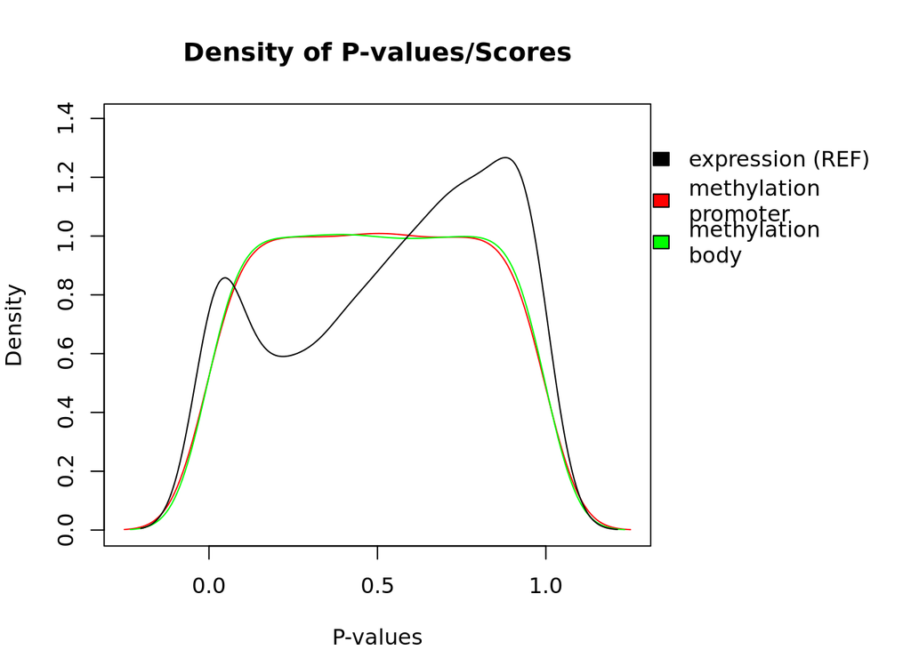

```r
#Plot density of p-values
#Note: plot directly to an image file to obtain proper dimensions/readable legend
plotDensityPval(pvalue_annotation = LUHMES_annotation, ref = "expression_pvalue")
```

```r
LUHMES_rescaled <- normalizePval(LUHMES_annotation, ref="expression", method="rescale")
```

```
## Plotting:  methylation_promoter
## Plotting:  methylation_body
```

```
## Plotting:  methylation_promoter
```

```
## Plotting:  methylation_body
```

```r
LUHMES_boxcox <- normalizePval(LUHMES_annotation, ref="expression", method="boxcox")
```

```
## Plotting:  methylation_promoter
## Plotting:  methylation_body
```

```
## Auto-detecting best transformation
```

```
## Plotting:  methylation_promoter
```

```
## Plotting:  methylation_body
```

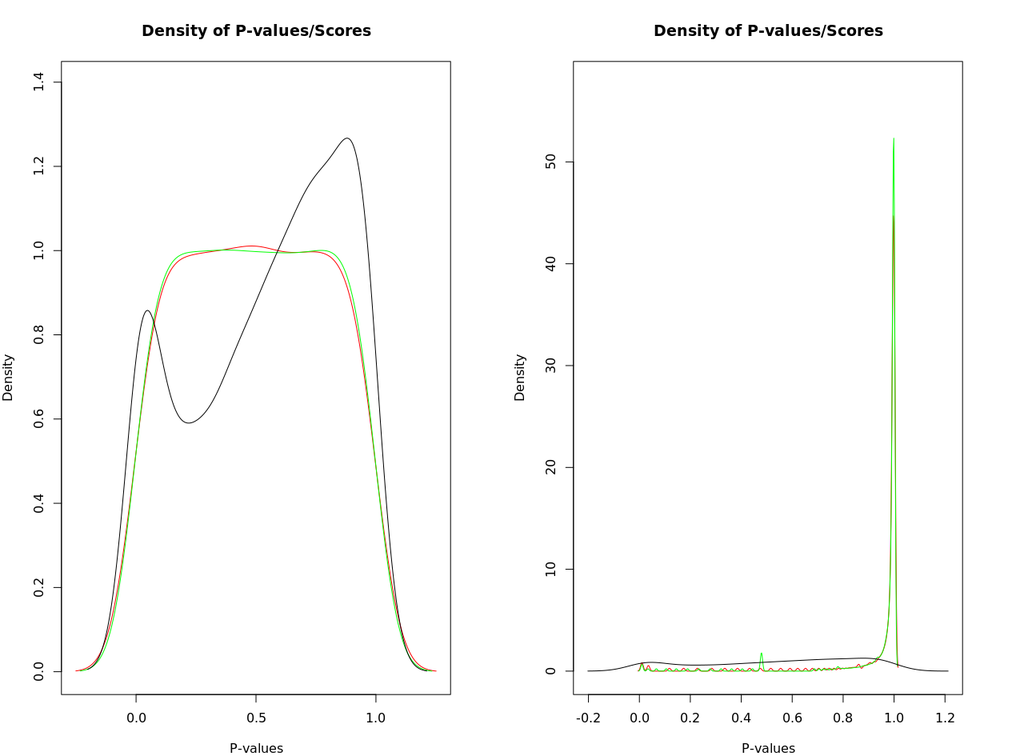

P-value distributions before and after "rescaled" normalization

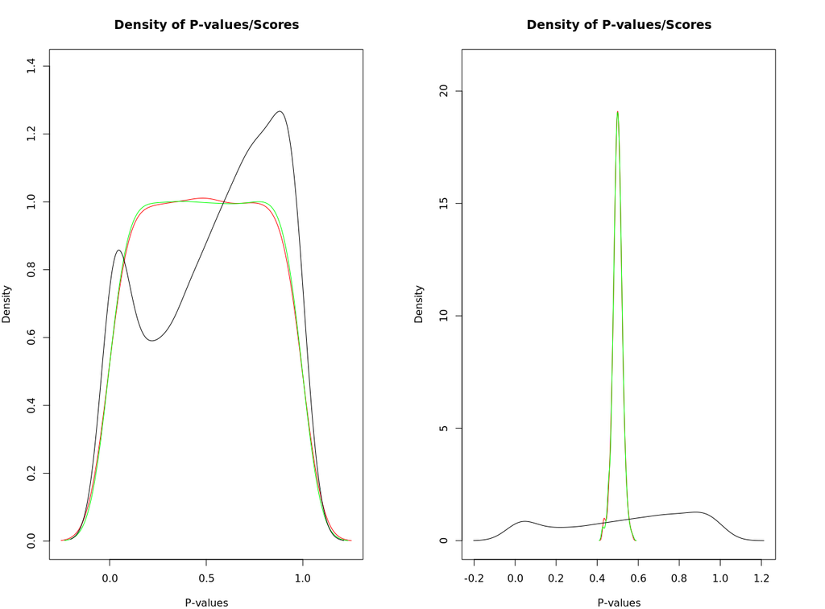

P-value distributions before and after "boxcox" normalization

### Weighting 'omics and re-scoring

The contribution of each 'omic (expression and DNA methylation at each feature) to the overall gene score can be weighted at this stage. Weights are specified a priori according to experimental context and research questions. Here, promoter DNA methylation and expression will be weighted higher, and body DNA methylation will be weighted lower.

```r
LUHMES_annotation_scored_bidirectional <- scorePval(LUHMES_annotation, weights = c(methylation_promoter=0.3, methylation_body=0.2, expression=0.5))
```

```
## The following weights are being applied
```

```
## methylation_promoter     methylation_body           expression
##                  0.3                  0.2                  0.5
```

```r
#Looking at gene score information
scores <- LUHMES_annotation_scored_bidirectional@score_data
scores
```

```
## *** Class P-Value Object, method Show ***
##  First 10 rows of pval_data data are shown:
##       methylation_promoter_pvalue methylation_body_pvalue expression_pvalue
## AAAS                           NA                      NA              0.71
## AASDH                   0.9962082                      NA                NA
## AATK                           NA                      NA              0.28
## ABCA2                          NA                      NA              0.46
## ABCA7                          NA                      NA              0.93
## ABCB9                          NA               0.9535740                NA
## ABCC5                          NA                      NA              0.53
## ABCC9                          NA                      NA              0.01
## ABCD1                          NA               0.1180987                NA
## ABCE1                          NA                      NA              0.62
##  First 10 rows of effect_data data are shown:
##       methylation_promoter_effect methylation_body_effect expression_effect
## AAAS                           NA                      NA       -0.10236375
## AASDH                 0.001234361                      NA                NA
## AATK                           NA                      NA       -0.53647204
## ABCA2                          NA                      NA       -0.33367591
## ABCA7                          NA                      NA       -0.06212006
## ABCB9                          NA            0.0004976577                NA
## ABCC5                          NA                      NA        0.14851842
## ABCC9                          NA                      NA       -0.69041440
## ABCD1                          NA            0.0209541352                NA
## ABCE1                          NA                      NA       -0.09353211
## Signs Index:
##   expression_relationship B_coeff                 name
## 1           bidirectional       2 methylation_promoter
## 2           bidirectional       2     methylation_body
##  First 10 Scores are shown:
##         AAAS        AASDH         AATK        ABCA2        ABCA7        ABCB9
##  1.180096232  0.007511019  3.586957475  2.541554024  0.273973924  0.046738205
##        ABCC5        ABCC9        ABCD1        ABCE1
##  2.111105598 14.853589003  2.093973068  1.611574047
## ******* End Show (pvalue.object) *******
```

```r
str(scores)
```

```
## Formal class 'PvalueObject' [package "SMITE"] with 8 slots
##   ..@ pval_data     :'data.frame':   1630 obs. of  3 variables:
##   .. ..$ methylation_promoter_pvalue: num [1:1630] NA 0.996 NA NA NA ...
##   .. ..$ methylation_body_pvalue    : num [1:1630] NA NA NA NA NA ...
##   .. ..$ expression_pvalue          : num [1:1630] 0.71 NA 0.28 0.46 0.93 NA 0.53 0.01 NA 0.62 ...
##   ..@ effect_data   :'data.frame':   1630 obs. of  3 variables:
##   .. ..$ methylation_promoter_effect: num [1:1630] NA 0.00123 NA NA NA ...
##   .. ..$ methylation_body_effect    : num [1:1630] NA NA NA NA NA ...
##   .. ..$ expression_effect          : num [1:1630] -0.1024 NA -0.5365 -0.3337 -0.0621 ...
##   ..@ genes         : chr [1:1630] "AAAS" "AASDH" "AATK" "ABCA2" ...
##   ..@ signs_index   :'data.frame':   2 obs. of  3 variables:
##   .. ..$ expression_relationship: chr [1:2] "bidirectional" "bidirectional"
##   .. ..$ B_coeff                : chr [1:2] "2" "2"
##   .. ..$ name                   : chr [1:2] "methylation_promoter" "methylation_body"
##   ..@ scores        :'data.frame':   1630 obs. of  1 variable:
##   .. ..$ scores: num [1:1630] 1.1801 0.00751 3.58696 2.54155 0.27397 ...
##   ..@ trans         : num(0)
##   ..@ scoring_vector: Named num [1:3] 0.3 0.2 0.5
##   .. ..- attr(*, "names")= chr [1:3] "methylation_promoter" "methylation_body" "expression"
##   ..@ module_output : list()
```

```r
save(LUHMES_annotation_scored_bidirectional, file="~/KoborLab/kobor_space/SWAG/Practicums/09_16_2021_SMITE_SS/LUHMES_annotation_scored_bidirectional.RData")
```

**OPTIONAL STOPPING POINT**

Now, each gene has a score; if you like, you can retrieve these genes and overall scores and/or feature-level scores for further interpretation (e.g. gene ontology enrichment). It is also a good idea to save the object at this stage. For a sanity check, feel free to check high-scoring genes against your original data (differential methylation/expression analysis) to ensure the results match with what you expect.

# Network analysis

## Annotate scores to reference network and find high-scoring sub-networks

For this next step we'll need a reference protein-protein interaction network for your organism, formatted as an igraph object. SMITE already includes a REACTOME igraph for the human genome that we can load in.

runSpinglass() is then applied to annotate gene scores to the network and discover sub-networks (modules) of genes with high scores (changes to DNA methylation and expression). The outcome you will get here depends on how you scored and weighted each modification in the previous steps: for example, if you weighted gene expression highly, most of your modules should have altered gene expression.

NOTE: The runSpinglass function has caused my RStudio session on the koborlab-hpc servers to freeze in the past. I recommend running that function in Terminal where it won't crash, saving the object, then loading the object back into RStudio for plotting.

### Spinglass function (run in Terminal)

```r
#################To run in Terminal
library(SMITE)
load("~/KoborLab/kobor_space/SWAG/Practicums/09_16_2021_SMITE_SS/LUHMES_annotation_scored_bidirectional.RData")

#load REACTOME interactome
load(system.file("data", "Reactome.Symbol.Igraph.rda", package = "SMITE"))

#Run spin-glass algorithm to determine best modules
LUHMES_spinglass <- runSpinglass(LUHMES_annotation_scored_bidirectional, network = REACTOME, maxsize = 50, num_iterations = 1000, random_alpha=0.05, node_alpha=0.05)
save(LUHMES_spinglass, file="~/KoborLab/kobor_space/SWAG/Practicums/09_16_2021_SMITE_SS/LUHMES_spinglass.RData")
#################
```

### Loading spinglass results into RStudio

```r
load("~/KoborLab/kobor_space/SWAG/Practicums/09_16_2021_SMITE_SS/LUHMES_spinglass.RData")
modules <- extractModules(LUHMES_spinglass)
modules
```

```
## $TPM1
## [1] "TPM1"  "MYL3"  "DMD"   "DES"   "TNNT2" "TLN1"  "LAMB1" "ITGA3"
```

## Plotting modules

Change the "which_network" argument to plot each of the different networks generated.

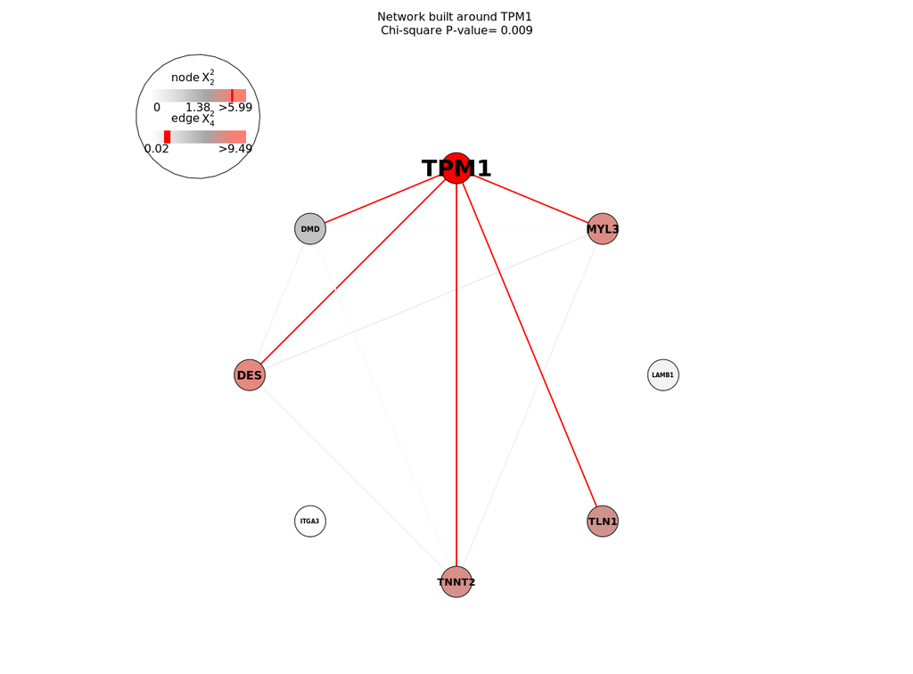

Simplified module plot

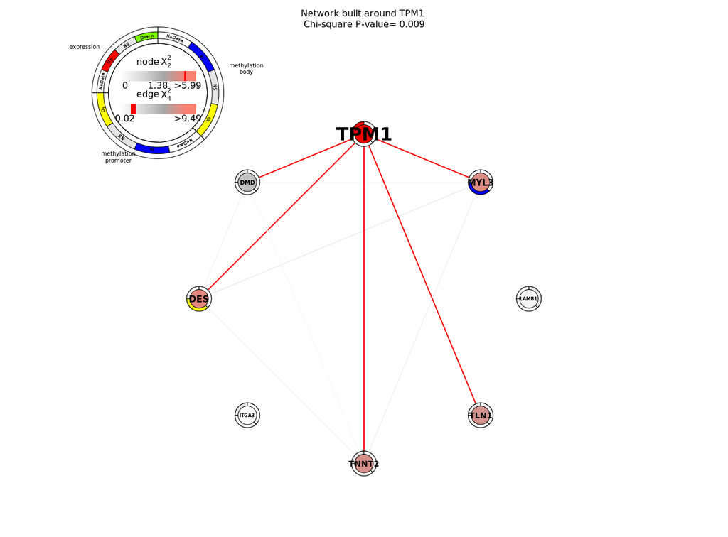

Detailed module plot

```r
#Simplified
plotModule2(LUHMES_spinglass, which_network=1, layout = "circle", label_scale = TRUE, compare_plot = FALSE, suppress_details = TRUE)

#Detailed
plotModule2(LUHMES_spinglass, which_network=1, layout = "circle", label_scale = TRUE, compare_plot = FALSE, suppress_details = FALSE)
```

# Optional exploratory analyses on networks

## How many genes have changes to each 'omic?

Using the below code, you can extract p-values for each feature and plot a summary of the number of genes with significant changes to promoter DNA methylation, body DNA methylation, and expression.

```r
#extracting p-value and effect size information from the PvalueObject
pval_df <- LUHMES_spinglass@score_data@pval_data
genes <- LUHMES_spinglass@score_data@genes
rownames(pval_df) <- genes

effect_df <- LUHMES_spinglass@score_data@effect_data
rownames(effect_df) <- genes

#getting only genes from significant modules
modules <- LUHMES_spinglass@score_data@module_output$modules
length(sig_genes <- unique(unlist(modules)))
```

```
## [1] 8
```

```r
pval_df_sub <- pval_df[rownames(pval_df) %in% sig_genes,]
effect_df_sub <- effect_df[rownames(effect_df) %in% sig_genes,]

#annotating modules
pval_df_sub$gene <- rownames(pval_df_sub)
pval_df_sub$module <- NA
pval_df_sub$module <- sapply(1:nrow(pval_df_sub), function(x) names(modules[grep(pval_df_sub$gene[x],modules)]))

#categorical variable summarizing sig/non-sig categories
pval_df_summary <- pval_df_sub[,1:4]

pval_df_summary$DNAm_promoter[complete.cases(pval_df_summary$methylation_promoter_pvalue)] <- ">0.05"
pval_df_summary[pval_df_summary$methylation_promoter_pvalue<=0.05 & complete.cases(pval_df_summary$methylation_promoter_pvalue),"DNAm_promoter"] <- "<=0.05"
pval_df_summary$DNAm_body[complete.cases(pval_df_summary$methylation_body_pvalue)] <- ">0.05"
pval_df_summary[pval_df_summary$methylation_body_pvalue<=0.05 & complete.cases(pval_df_summary$methylation_body_pvalue),"DNAm_body"] <- "<=0.05"

pval_df_summary$Expression[complete.cases(pval_df_summary$expression_pvalue)] <- ">0.05"
pval_df_summary[pval_df_summary$expression_pvalue<=0.05 & complete.cases(pval_df_summary$expression_pvalue),"Expression"] <- "<=0.05"

#getting the number of genes with significant/non-significant p-values for each feature/'omic
unlist(apply(pval_df_summary[,5:7], 2, function(x) summary(as.factor(x))))
```

```
## DNAm_promoter.<=0.05   DNAm_promoter.NA's      DNAm_body.>0.05
##                    2                    6                    1
##       DNAm_body.NA's    Expression.<=0.05     Expression.>0.05
##                    7                    1                    4
##      Expression.NA's
##                    3
```

```r
sig_genes <- unique(unlist(apply(pval_df_summary[,5:7], 2, function(x) grep("<=0.05",x))))
nrow(pval_df_summary_sig <- pval_df_summary[sig_genes,])
```

```
## [1] 3
```

```r
pval_df_summary_sig$gene
```

```
## [1] "DES"  "MYL3" "TPM1"
```

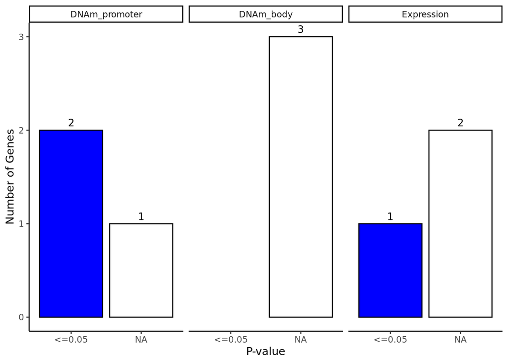

```r
pval_df_melt <- melt(pval_df_summary_sig[,4:7], id.vars="gene")
ggplot(pval_df_melt, aes(x=value, fill=value)) + geom_bar(stat="count", show.legend=FALSE, col="black") + facet_wrap(~variable) + theme_classic() + ylab("Number of Genes") + xlab("P-value") + scale_fill_manual(values=c("blue","white")) + geom_text(stat="count", aes(label = after_stat(count)), vjust=-0.5, size=3.5)
```

## Gene ontology enrichment with GOseq

GOseq is a gene ontology enrichment method built for RNA-seq data ( [Young et al., 2010](https://genomebiology.biomedcentral.com/articles/10.1186/gb-2010-11-2-r14) ). It reduces bias based on long and highly expressed transcripts.

runGOseq() requires a bed file that specifies gene names, gene coordinates, and bias data (number of probes annotated to the gene, gene length, etc). By default, the function returns terms signficant at FDR < 0.05 (this is tunable).

Below is an example of GOseq code.

```r
LUHMES_spinglass <- runGOseq(LUHMES_spinglass, coverage = read.table(system.file("extdata", "hg19_symbol_hpaii.sites.inbodyand2kbupstream.bed.gz", package = "SMITE")), type = "reactome")
GO_results <- extractGOseq(LUHMES_spinglass)
```

Although GOseq is built into SMITE, you can also use different gene/pathway enrichment tools on your data as desired!